# Chapter 4 Lab - Classification

```python
# !pip install seaborn==0.9.0
import numpy as np
import pandas as pd
import scipy
import scipy.stats
import matplotlib.pyplot as plt
import seaborn as sns
import statsmodels.api as sm
import statsmodels.formula.api as smf
import statsmodels
import patsy
import math
sns.set()
import warnings
warnings.simplefilter('ignore',FutureWarning)
# 4.6.3
from sklearn.discriminant_analysis import LinearDiscriminantAnalysis
# 4.6.4
from sklearn.discriminant_analysis import QuadraticDiscriminantAnalysis
# 4.6.5
from sklearn.neighbors import KNeighborsClassifier
# 4.6.6
import sklearn.preprocessing
# sklearn better than statsmodels?
from sklearn.linear_model import LogisticRegression
```

```python
# debug printing appears immediately
import sys
def eprint(*args, **kwargs):
    print(*args, file=sys.stderr, **kwargs)
```

```python
smarket_1 = pd.read_csv('Smarket.csv', na_values='?');
#smarket_1 = pd.read_csv('http://vincentarelbundock.github.io/Rdatasets/csv/ISLR/Smarket.csv', na_values = '?')
```

```python
smarket = smarket_1.drop(columns=['Unnamed: 0'])
```

```python
smarket.corr()
```

|  | Year | Lag1 | Lag2 | Lag3 | Lag4 | Lag5 | Volume | Today |
| --- | --- | --- | --- | --- | --- | --- | --- | --- |
| Year | 1.000000 | 0.029700 | 0.030596 | 0.033195 | 0.035689 | 0.029788 | 0.539006 | 0.030095 |
| Lag1 | 0.029700 | 1.000000 | -0.026294 | -0.010803 | -0.002986 | -0.005675 | 0.040910 | -0.026155 |
| Lag2 | 0.030596 | -0.026294 | 1.000000 | -0.025897 | -0.010854 | -0.003558 | -0.043383 | -0.010250 |
| Lag3 | 0.033195 | -0.010803 | -0.025897 | 1.000000 | -0.024051 | -0.018808 | -0.041824 | -0.002448 |
| Lag4 | 0.035689 | -0.002986 | -0.010854 | -0.024051 | 1.000000 | -0.027084 | -0.048414 | -0.006900 |
| Lag5 | 0.029788 | -0.005675 | -0.003558 | -0.018808 | -0.027084 | 1.000000 | -0.022002 | -0.034860 |
| Volume | 0.539006 | 0.040910 | -0.043383 | -0.041824 | -0.048414 | -0.022002 | 1.000000 | 0.014592 |
| Today | 0.030095 | -0.026155 | -0.010250 | -0.002448 | -0.006900 | -0.034860 | 0.014592 | 1.000000 |

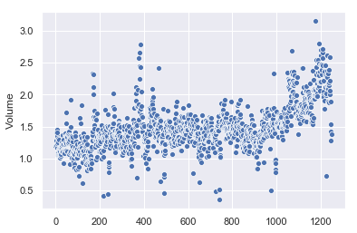

```python
sns.scatterplot(x=smarket.index, y='Volume', data=smarket);
```

## 4.6.2 Logistic Regression

Informative article on [logistic regression (logit) versus other possible ways to connect 0 to 1 like probit](https://stats.stackexchange.com/questions/20523/difference-between-logit-and-probit-models#30909).

There are some snags using StatsModels to do logistic regression.

The biggest issue is that the formula processor from Patsy does not directly work on the outputs (y values). Patsy generates two complementary columns that sum to all ones. Since you can only use one column for the response, you need to pick one. At this point you could just convert the original Yes/No answers to 1/0 instead... so I do that.

[LogitResults](http://www.statsmodels.org/dev/generated/statsmodels.discrete.discrete_model.LogitResults.html) are the output of the fitting process. Some important fields of `LogitResults` are listed here:

- `params`: Coefficients.
- `pvalues`
- `fittedvalues`
- `bse`: Coefficient standard errors.
- `aic`: A measure of model fit.

There are also methods to get items like residual deviance. Check the documentation.

```python
smarket["DirectionUp"] = np.array(
    [1 if up else 0 for up in smarket.Direction == "Up"])
```

```python
dm = sm.Logit.from_formula("DirectionUp ~ Lag1+Lag2+Lag3+Lag4+Lag5+Volume", data=smarket).fit()
```

```
Optimization terminated successfully.
         Current function value: 0.691034
         Iterations 4
```

```python
dm.params
```

```
Intercept   -0.126000
Lag1        -0.073074
Lag2        -0.042301
Lag3         0.011085
Lag4         0.009359
Lag5         0.010313
Volume       0.135441
dtype: float64
```

```python
dm.pvalues
```

```
Intercept    0.600700
Lag1         0.145232
Lag2         0.398352
Lag3         0.824334
Lag4         0.851445
Lag5         0.834998
Volume       0.392404
dtype: float64
```

```python
dm.fittedvalues.head() # theres lots, head is to not see them all
```

```
0    0.028338
1   -0.074162
2   -0.075480
3    0.060908
4    0.043131
dtype: float64
```

```python
dm.aic
```

```
1741.5840942032346
```

```python
dm.llf
```

```
-863.7920471016173
```

```python
dm.bse
```

```
Intercept    0.240737
Lag1         0.050168
Lag2         0.050086
Lag3         0.049939
Lag4         0.049974
Lag5         0.049512
Volume       0.158361
dtype: float64
```

Predictions for the existing data set come from the `predict()` method. To get predictions for another dataset, make another data frame.

```python
predictions_1 = dm.predict();
len(predictions_1)
```

```
1250
```

```python
smarket.head()
```

|  | Year | Lag1 | Lag2 | Lag3 | Lag4 | Lag5 | Volume | Today | Direction | DirectionUp |
| --- | --- | --- | --- | --- | --- | --- | --- | --- | --- | --- |
| 0 | 2001 | 0.381 | -0.192 | -2.624 | -1.055 | 5.010 | 1.1913 | 0.959 | Up | 1 |
| 1 | 2001 | 0.959 | 0.381 | -0.192 | -2.624 | -1.055 | 1.2965 | 1.032 | Up | 1 |
| 2 | 2001 | 1.032 | 0.959 | 0.381 | -0.192 | -2.624 | 1.4112 | -0.623 | Down | 0 |
| 3 | 2001 | -0.623 | 1.032 | 0.959 | 0.381 | -0.192 | 1.2760 | 0.614 | Up | 1 |
| 4 | 2001 | 0.614 | -0.623 | 1.032 | 0.959 | 0.381 | 1.2057 | 0.213 | Up | 1 |

Make a new data frame to get the probability of "up" for a given set of predictors.

```python
new_prediction_data = pd.DataFrame({'Lag1': 0.8, 'Lag2': 0.5, 'Lag3': -0.5, 'Lag4': -0.2, 'Lag5': 3, 'Volume': 7 },
                                  index = [0])
predictions_2 = dm.predict(new_prediction_data)
predictions_2
```

```
0    0.682655
dtype: float64
```

We still need to make the confusion matrix and do a prediction based on some data. In the confusion matrix, we need to turn the probabilities into either 0 or 1 decisions, so round them. In a different case, you could use an "if" statement.

```python
up_predicted = pd.Series( dm.predict().round(), name = "Predicted")
up_actual = pd.Series(smarket.DirectionUp, name = "Actual")
confusion_matrix = pd.crosstab(up_actual, up_predicted)
confusion_matrix
```

| Predicted Actual | 0.0 | 1.0 |
| --- | --- | --- |
| 0 | 145 | 457 |
| 1 | 141 | 507 |

```python
correct_count = confusion_matrix[0][0] + confusion_matrix[1][1]
total = len(smarket)
print("supposed accuracy (but bad): ", correct_count / total)
```

```
supposed accuracy (but bad):  0.5216
```

Assessing a model based on data that you used for training is kind of suspicious. To keep things legit, we need to separate out data and not use it for training, only to check to see the quality of the model. The code below selects a random 10% to be the held out data.

```python
test_data = np.random.random(1250) < 0.10
#test_data = smarket.Year >= 2005 # book does this
training_data = ~test_data
```

```python
sum(test_data)
```

```
130
```

```python
dm_parts = sm.Logit.from_formula("DirectionUp ~ Lag1+Lag2+Lag3+Lag4+Lag5+Volume", data=smarket[training_data]).fit()
correct = pd.Series(smarket.DirectionUp[test_data], name = "Actual")
predicted = pd.Series(dm_parts.predict(smarket[test_data]).round(), name="Predicted")
confusion_matrix = pd.crosstab(correct,predicted)
confusion_matrix
```

```
Optimization terminated successfully.
         Current function value: 0.690159
         Iterations 4
```

| Predicted Actual | 0.0 | 1.0 |
| --- | --- | --- |
| 0 | 14 | 51 |
| 1 | 12 | 53 |

```python
accuracy = np.mean(correct == predicted)
print("accuracy (done right): ", accuracy)
```

```
accuracy (done right):  0.5153846153846153
```

```python
error_rate = np.mean(correct != predicted)
error_rate
```

```
0.4846153846153846
```

Just predicting "up" gives only a 52% accuracy. That is called predicting the "baseline rate". Your prediction method should do better than that to be useful.

```python
sum(smarket.DirectionUp == 1) / len(smarket)
```

```
0.5184
```

Book says try again with just Lag1 and Lag2......... but that does not seem to do any better for me.

```python
dm_parts = sm.Logit.from_formula("DirectionUp ~ Lag1+Lag2", data=smarket[training_data]).fit()
correct = pd.Series(smarket.DirectionUp[test_data], name = "Actual")
predicted = pd.Series(dm_parts.predict(smarket[test_data]).round(), name="Predicted")
accuracy = np.mean(correct == predicted)
accuracy
```

```
Optimization terminated successfully.
         Current function value: 0.690749
         Iterations 4
```

```
0.5
```

As usual, the `predict` method gets you probabilities for the value you predicted - in this case, `DirectionUp`. Both of the values below are solidly in the middle of the probability range, but 0.48 would be predicted "Down" and 0.50 would be "Up".

```python
more_demo_data = pd.DataFrame({'Lag1': [1.2, 1.1], 'Lag2': [1.5, -0.8]})
dm_parts.predict(more_demo_data)
```

```
0    0.479911
1    0.501970
dtype: float64
```

## 4.6.3 Linear Discriminant Analysis

The biggest thing I notice about using LDA is that it does not have the nice interface of Pandas DataFrames and Patsy formulas built in. No actual deficiencies noted. R has better summarization info for LDA, but do you really use it?

**Note**: Do not include a constant term in the design matrix for Linear Discriminant Analysis (also not for Quadratic D.A. in the next section)!

```python
test_data = np.random.random(1250) < 0.10
train_data = ~ test_data
lda = LinearDiscriminantAnalysis()
X = patsy.dmatrix("Lag1+Lag2+0", data=smarket[train_data])
y = smarket.DirectionUp[train_data]
lda_fit = lda.fit(X,y)
```

Assess the quality of your model by seeing what fraction of your predictions are correct on the test data. The cells below show 46% accuracy.

```python
X_test = patsy.dmatrix("Lag1+Lag2+0", data=smarket[test_data])
ypredict = lda_fit.predict(X_test)
ycorrect = smarket.DirectionUp[test_data]
np.mean(ypredict == ycorrect)
```

```
0.46218487394957986
```

The `score` method returns the accuracy without you having to do any of the work by hand. LDA gives models that can `score`, but not all classifiers do.

```python
lda_fit.score(X_test, ycorrect)
```

```
0.46218487394957986
```

Predict the probabilities for each class (one column per class). The book explains that these are "posterior probabilities" (meaning after the model is fitted). Check!

```python
lda_test_predictions = lda_fit.predict_proba(X_test)
lda_test_predictions[1:5]
```

```
array([[0.48110417, 0.51889583],
       [0.45028127, 0.54971873],
       [0.44258594, 0.55741406],
       [0.52719747, 0.47280253]])
```

Decision function gives a number, positive is one class, negative is the other.

```python
lda.decision_function(X_test)[1:5]
```

```
array([ 0.07561932,  0.1995343 ,  0.23067368, -0.10889735])
```

The book suggests we try changing the probability threshhold. How many observations are 55% certain to get class 1 (which is the second column)?

```python
np.sum(lda_test_predictions[:,1] > 0.55)
```

```
20
```

## 4.6.4 Quadratic Discriminant Analysis

Quadratic discriminant analysis (QDA) works the same as LDA. The difference is that the decision boundaries can be more flexible. Read the book! The coding seems the same. Note the nice high score, almost 60% right on the test data when you split training and test data by year. Unfortunately when you randomly choose about 10% of the data for test cases, the amazing prediction power goes away and you are stuck with a lousy 45% correct.

```python
#test_data = np.random.random(1250) < 0.10
test_data = smarket.Year >= 2005
train_data = ~ test_data
qda = QuadraticDiscriminantAnalysis()
X = patsy.dmatrix("Lag1+Lag2+0", data=smarket[train_data])
y = smarket.DirectionUp[train_data]
qda_fit = qda.fit(X,y)

X_test = patsy.dmatrix("Lag1+Lag2+0", data=smarket[test_data])
ypredict = qda_fit.predict(X_test)
ycorrect = smarket.DirectionUp[test_data]
np.mean(ypredict == ycorrect)
```

```
0.5992063492063492
```

## 4.6.5 K-nearest neighbors

K-nearest neighbors is very similar to LDA and QDA in its execution.

There is also a related classifier that uses all of the points within a given radius to classify a point. Good when the points are not all evenly distributed in the sample space.

```python
neighbors = 3
knn = KNeighborsClassifier(neighbors)
knn_fit = knn.fit(X, y)
knn_predict = knn.predict(X_test)
```

```python
np.mean(knn_predict == ycorrect)
```

```
0.5317460317460317
```

Investigate the accuracy of KNN as the number of neighbors increases.

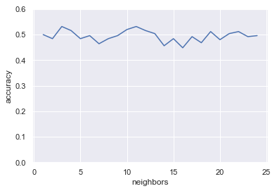

```python
X_train = patsy.dmatrix("Lag1+Lag2+0", data=smarket[train_data])
y_train = smarket.DirectionUp[train_data]
X_test = patsy.dmatrix("Lag1+Lag2+0", data=smarket[test_data])
y_test = smarket.DirectionUp[test_data]

def knn_accuracy(neighbors):
    knn = KNeighborsClassifier(neighbors)
    knn_fit = knn.fit(X_train, y_train)
    knn_predict = knn.predict(X_test)
    return np.mean(knn_predict == ycorrect)

ns = np.arange(1,25)
y = [knn_accuracy(n) for n in ns]
ax = sns.lineplot(x=ns,y=y);
ax.set_ylim([0,0.6]);
ax.set_xlabel('neighbors');
ax.set_ylabel('accuracy');
```

## 4.5.6 Example: Caravan insurance

Important point #1: standardize your data before you do KNN. Or anything, really. Use [sklearn.preprocessing.scale](https://scikit-learn.org/stable/modules/generated/sklearn.preprocessing.scale.html).

[Caravan dataset documentation](http://vincentarelbundock.github.io/Rdatasets/doc/ISLR/Caravan.html). Column 86, 'Purchase', indicates 'Yes' or 'No' did the person purchase a policy.

```python
#df_caravan_1 = pd.read_csv('https://vincentarelbundock.github.io/Rdatasets/csv/ISLR/Caravan.csv')
df_caravan_1 = pd.read_csv('Caravan.csv')
```

```python
df_caravan = df_caravan_1.drop(columns=['Unnamed: 0'])
```

```python
predictors = set(df_caravan.columns) - set(['Purchase'])
purchase = df_caravan.Purchase
```

How many data points are there? How many purchases vs not? What is the rate of sales?

```python
purchase.count()
```

```
5822
```

```python
purchase.value_counts()
```

```
No     5474
Yes     348
Name: Purchase, dtype: int64
```

```python
purchase.value_counts() / purchase.count()
```

```
No     0.940227
Yes    0.059773
Name: Purchase, dtype: float64
```

SciKit-Learn has a preprocessing module that will automatically adjust your data to have mean zero and standard deviation one. [sklearn.preprocessing.scale](https://scikit-learn.org/stable/modules/generated/sklearn.preprocessing.scale.html)

```python
test = df_caravan.index < 1000
train = ~ test
X_scaled = sklearn.preprocessing.scale(df_caravan[list(predictors)])
X = X_scaled[train]
y = purchase[train]
knn = KNeighborsClassifier(1)
knn_fit = knn.fit(X,y)
```

```python
y_correct = purchase[test]
X_predict = X_scaled[test]
y_predict = knn_fit.predict(X_predict)
accuracy = np.mean(y_correct == y_predict)
errors = 1-accuracy
accuracy
```

```
0.882
```

```python
errors
```

```
0.118
```

How many people who are predicted to buy insurance actually buy it? We want to know if we should concentrate on the people who the model says will buy. According to this math about 11+% of those predictions are correct.

```python
buy = y_predict == 'Yes'
correct_predictions = y_correct == y_predict
np.mean(correct_predictions[buy])
```

```
0.11688311688311688
```

We automate the process of finding out how many of the predicted buyers actually buy so we can see how changing the number of neighbors affects the percent of predicted buys who actually buy.

```python
test = df_caravan.index < 1000
train = ~ test
X_scaled = sklearn.preprocessing.scale(df_caravan[list(predictors)])

X = X_scaled[train]
y = purchase[train]
y_correct = purchase[test]
X_predict = X_scaled[test]

def knn_success_rate(neighbors):
    knn = KNeighborsClassifier(neighbors)
    knn_fit = knn.fit(X,y)
    y_predict = knn_fit.predict(X_predict)
    correct = y_correct == y_predict
    buy = y_predict == 'Yes'
    return np.mean(correct[buy])
```

We see that as the number of neighbors goes up, the prediction rate goes up. The book does not carry this analysis far enough to get to the suspicious part.... 100% prediction rate with k=9 neighbors. As k increases, the pool of "Yes" reponses shrinks to almost zero.

```python
neighbors = np.arange(1,10)
brate = [knn_success_rate(k) for k in neighbors]
```

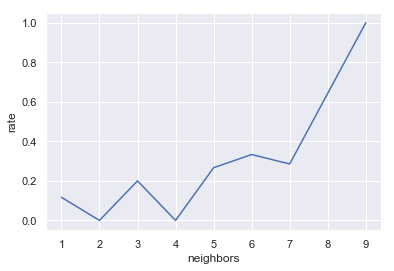

```python
pframe = pd.DataFrame({'neighbors': neighbors, 'rate': brate})
#odds = [ n%2 == 1 for n in neighbors ] # are odds better than evens?
sns.lineplot(x='neighbors',y='rate',data=pframe);
```

```python
def score(correct):
    if len(correct) == 0: return 0
    return np.mean(correct)
```

Next we investigate a "saturated" logistic model and find out the rate of predictions who buy. When you use a cutoff of 50%, the model is terrible, but if you change the cutoff to 25% or so, it gets better.

I had trouble with this. Get the raw probabilities with `predict_proba`. If you train with answers being strings, then when you predict you will get those strings, so make your life easier, train with numbers for the response. Predictions from `predict_proba` have one column for each possible predicted value, so in this case even though it we are modeling a binary response we get two columns (for 0 and 1).

```python
test = np.zeros(len(df_caravan), dtype=bool)
test[0:1000] = True
test = np.random.random(len(df_caravan)) < 0.10
train = ~ test
X_scaled = sklearn.preprocessing.scale(df_caravan[list(predictors)])

noyes = np.vectorize(lambda s: 1 if s=='Yes' else 0)

X = X_scaled[train]
y = noyes(purchase[train])
y_correct = noyes(purchase[test])
X_predict = X_scaled[test]

model_fit = LogisticRegression().fit(X,y)
y_predict_p = model_fit.predict_proba(X_predict)
y_predict = (y_predict_p > 0.25)[:,1]  # column 0 = No, 1=Yes
correct = y_correct == y_predict
buy = y_predict == 1
print("Predicted to purchase:",np.sum(buy))
print("Score:", score(correct[buy]))
```

```
Predicted to purchase: 19
Score: 0.3157894736842105
```

```python
noyes = np.vectorize(lambda s: 1 if s=='Yes' else 0)
X_scaled = sklearn.preprocessing.scale(df_caravan[list(predictors)])

def caravan_predict(test, threshold = 0.25):
    """Given test vector of length df_caravan, return (score, number of yes).
    The threshold parameter controls the probability at which a yes is returned."""
    train = ~ test

    X = X_scaled[train]
    y = noyes(purchase[train])
    y_correct = noyes(purchase[test])
    X_predict = X_scaled[test]

    model_fit = LogisticRegression().fit(X,y)
    y_predict_p = model_fit.predict_proba(X_predict)
    y_predict = (y_predict_p > threshold)[:,1]  # column 0 = No, 1=Yes
    correct = y_correct == y_predict
    buy = y_predict == 1
    return (score(correct[buy]), np.sum(buy))
```

```python
results = np.array([caravan_predict(np.random.random(len(df_caravan)) < 0.10)
                    for _ in range(20)]) # 100 takes a long time...
```

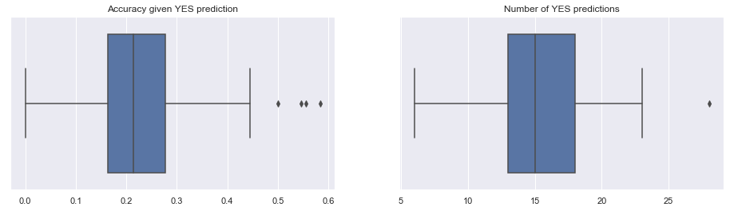

```python
fig, ax = plt.subplots(1,2,figsize=(16,4))

ax[0].set_title("Accuracy given YES prediction")
sns.boxplot(results[:,0], ax=ax[0]);

ax[1].set_title("Number of YES predictions")
sns.boxplot(results[:,1], ax=ax[1]);
```

```python
np.mean(results,axis=0)
```

```
array([ 0.22785236, 15.5       ])
```

We study the threshold and find that roughly 20-30% threshold has the same accuracy on predicted yes values (about 22%). This was compute-intensive.

```python
def threshold_finder_2(thresh):
    test_set = np.random.random(len(df_caravan)) < 0.10
    return caravan_predict(test_set,
                           threshold = thresh)
threshold_finder_2v = np.vectorize(threshold_finder_2)

def threshold_finder_1(thresh, N=50):
    return np.mean([threshold_finder_2(thresh) for _ in range(N)],
                   axis=0)

def threshold_finder(thresholds, N=50):
    return np.array([threshold_finder_1(t, N=N) for t in thresholds])
```

```python
## This takes a long time to run (maybe 15 minutes on my computer)
#ts = np.linspace(0.01,0.50,50)
#vals = threshold_finder(ts)
long_work = pd.read_csv('insurance-predictions.csv')
ts = long_work['threshold']
vals = np.zeros((len(long_work),2))
vals[:,0] = long_work['accuracy']
vals[:,1] = long_work['predictedYES']
```

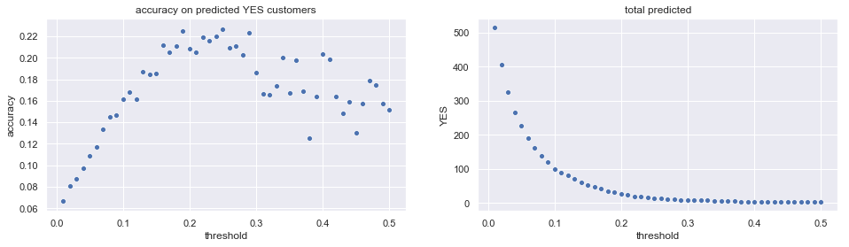

```python
fig, axs = plt.subplots(1,2,figsize=(16,4))
axs[0].set_title('accuracy on predicted YES customers')
axs[0].set_xlabel('threshold')
axs[0].set_ylabel('accuracy')
sns.scatterplot(ts, vals[:,0], ax=axs[0]);
#axs[1].set_title('number of predictes YES customers')
axs[1].set_title('total predicted')
axs[1].set_xlabel('threshold')
axs[1].set_ylabel('YES')
sns.scatterplot(ts, vals[:,1], ax=axs[1]);
```

```python
#long_work = pd.DataFrame({'threshold':ts, 'accuracy': vals[:,0], 'predictedYES': vals[:,1]});
#long_work.to_csv('insurance-predictions.csv')
```